# Assignment 3: Hypothesis Testing

Univeristy of Washington - Data Science Certification - Method for Data Analysis

Josh Jensen

July 20, 2016

### Set up

First lets load libraries and data, as well as standardizing the column names.

```r
# load libraries
library(dplyr)
library(readr)
library(ggplot2)

# read in data
auto_prices <- read_csv('Automobile price data _Raw_.csv', na = c('','?'))

# rename columns
colnames(auto_prices) <- gsub('-','_', colnames(auto_prices))
```

### Problem 1: Test normality of price & log price

Compare and test normality the distributions of price and log price - two tests

#### Transformations

Lets log transform the price data to `log_price`. As well, apply a z normalization to the `price` and `log_price` in order to standardize the Q-Q plots and use in Kolmogorov-Smirnov and Shapiro-Wilk normality tests.

```r
# create log_price
auto_prices$log_price <- log(auto_prices$price)

# z normalize prices
auto_prices$z_price <- (auto_prices$price - mean(auto_prices$price, na.rm = T)) / sd(auto_prices$price, na.rm = T)
auto_prices$z_log_price <- (auto_prices$log_price - mean(auto_prices$log_price, na.rm = T)) / sd(auto_prices$log_price, na.rm = T)
```

#### Inspect distributions

Lets inspect how `z_price` is distributed by looking at a histogram and Q-Q plot.

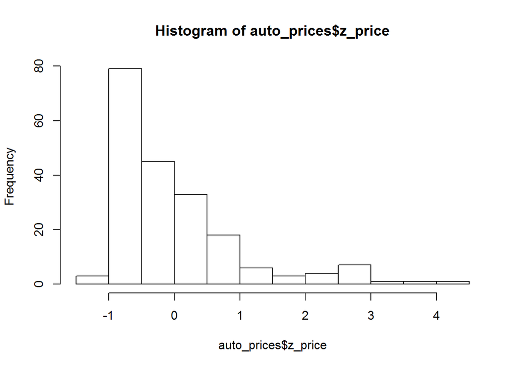

```r
hist(auto_prices$z_price)
```

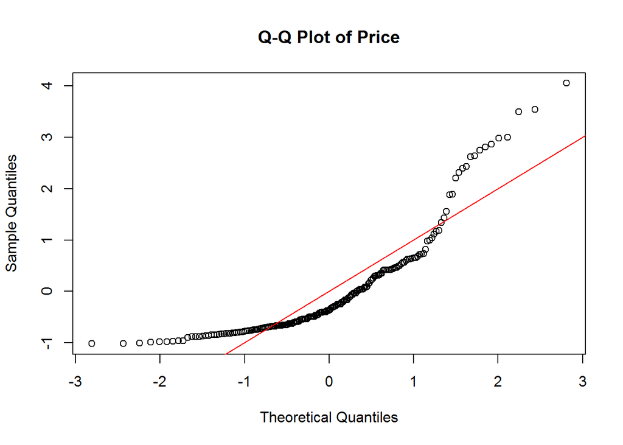

```r
qqnorm(auto_prices$z_price, main = 'Q-Q Plot of Price')
abline(a=0, b=1, col='red')
```

First inspection looks pretty far off of being normally distributed.

Now lets inspect the distribution of `z_log_price`.

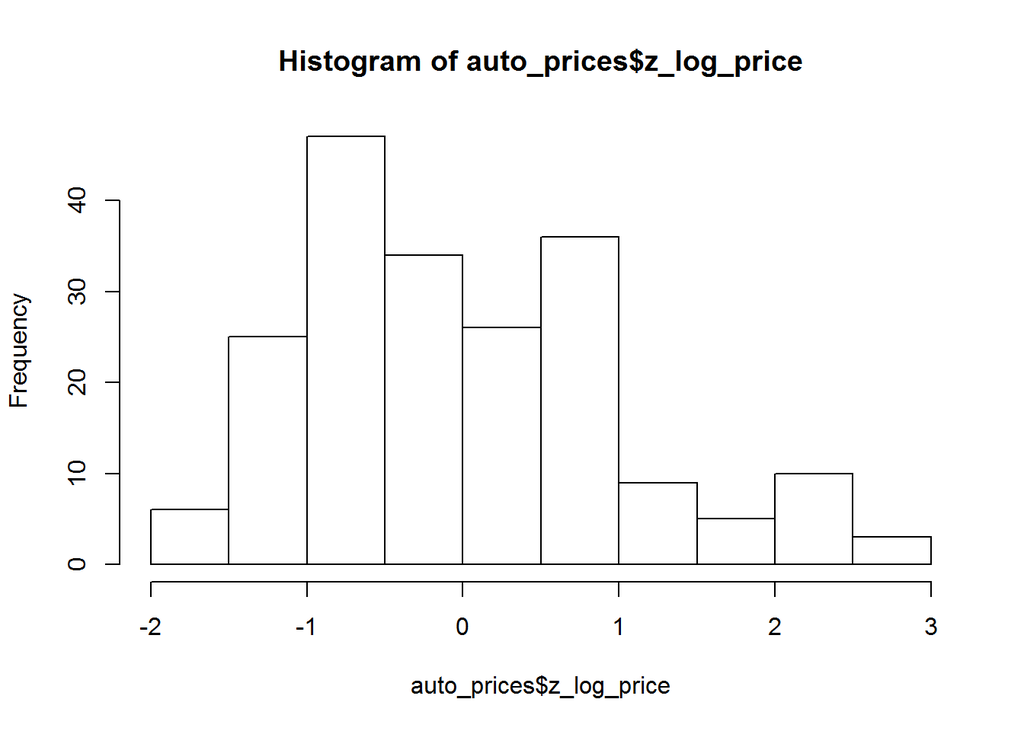

```r
hist(auto_prices$z_log_price)
```

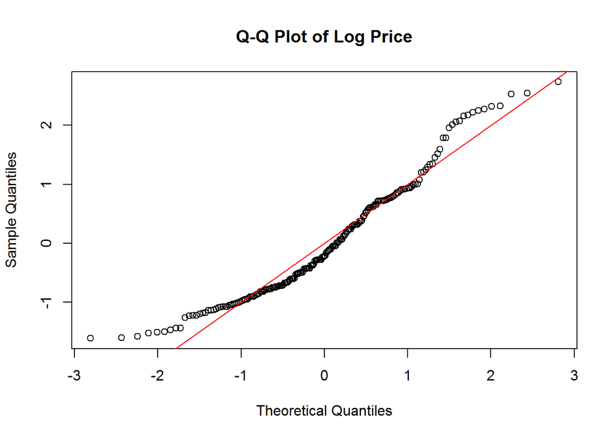

```r
qqnorm(auto_prices$z_log_price, main = 'Q-Q Plot of Log Price')
abline(a=0, b=1, col='red')
```

`z_log_price` looks to be a lot closer to being normally distributed. Now lets formally test the normality of both.

#### K-S Tests (Kolmogorov-Smirnov test)

First we’ll test against normality using the Kolmogorov-Smirnov test for both `z_price` and `z_log_price`. In each case I’ll state the null and alternative hypothesis.

- *Null Hypothesis:* `z_price` is normally distributed
- *Alternative Hypothesis:* `z_price` is not normally distributed

```r
ks.test(auto_prices$z_price, pnorm)
```

```
##
##  One-sample Kolmogorov-Smirnov test
##
## data:  auto_prices$z_price
## D = 0.15437, p-value = 0.0001383
## alternative hypothesis: two-sided
```

Under 95% confidence, we reject the null hypothesis of `z_price` being normally distributed.

- *Null Hypothesis:* `z_log_price` is normally distributed
- *Alternative Hypothesis:* `z_log_price` is not normally distributed

```r
ks.test(auto_prices$z_log_price, pnorm)
```

```
##
##  One-sample Kolmogorov-Smirnov test
##
## data:  auto_prices$z_log_price
## D = 0.097552, p-value = 0.04361
## alternative hypothesis: two-sided
```

Under 95% confidence, we reject the null hypothesis of `z_log_price` being normally distributed.

#### Shapiro-Wilk Normality Test

Now for `z_price` and `z_log_price` we’ll test against normality using the Shapiro-Wilk Normality test.

- *Null Hypothesis:* `z_price` is normally distributed
- *Alternative Hypothesis:* `z_price` is not normally distributed

```r
shapiro.test(auto_prices$z_price)
```

```
##
##  Shapiro-Wilk normality test
##
## data:  auto_prices$z_price
## W = 0.79852, p-value = 2.216e-15
```

Under 95% confidence, we reject the null hypothesis of `z_price` being normally distributed.

- *Null Hypothesis:* `z_log_price` is normally distributed
- *Alternative Hypothesis:* `z_log_price` is not normally distributed

```r
shapiro.test(auto_prices$z_log_price)
```

```
##
##  Shapiro-Wilk normality test
##
## data:  auto_prices$z_log_price
## W = 0.949, p-value = 1.432e-06
```

Under 95% confidence, we reject the null hypothesis of `z_log_price` being normally distributed.

#### Conclusion

In all cases, for both Kolmogorov-Smirnov and Shapiro-Wilk tests, we reject the null hypotheses of both `z_price` and `z_log_price` being normally distributed.

### Problem 2: Hypothesis testing on difference of means of significance of price (log price)

Test significance of price (log price) stratified by a) fuel type, b) aspiration, and c) rear vs. front wheel drive

#### Fuel type

Lets first inspect `fuel_type`.

```r
table(auto_prices$fuel_type)
```

```
##
## diesel    gas
##     20    185
```

```r
auto_prices %>%
  group_by(fuel_type) %>%
  summarise(mean_log_price = mean(log_price, na.rm=T),
            sd_log_price = sd(log_price, na.rm=T),
            se_log_price = sd(log_price, na.rm=T)/n())
```

```
## Source: local data frame [2 x 4]
##
##   fuel_type mean_log_price sd_log_price se_log_price
##       (chr)          (dbl)        (dbl)        (dbl)
## 1    diesel       9.557420    0.4880124  0.024400618
## 2       gas       9.327208    0.4998436  0.002701857
```

Now lets perform a two-tailed t-test where:

- *Null Hypothesis:* For `log_price`, $\mu_{diesel} = \mu_{gas}$
- *Alternative Hypothesis:* For `log_price`, $\mu_{diesel} \neq \mu_{gas}$

```r
diesel <- auto_prices[auto_prices$fuel_type == 'diesel',]
gas <- auto_prices[auto_prices$fuel_type == 'gas',]

t.test(diesel$log_price, gas$log_price, alternative = 'two.sided')
```

```
##
##  Welch Two Sample t-test
##
## data:  diesel$log_price and gas$log_price
## t = 1.9971, df = 23.627, p-value = 0.05746
## alternative hypothesis: true difference in means is not equal to 0
## 95 percent confidence interval:
##  -0.007901153  0.468325711
## sample estimates:
## mean of x mean of y
##  9.557420  9.327208
```

Under 95% confidence, we fail to reject the null hypothesis of the population mean `log_price` being equal for diesel and gas.

#### Aspiration

Similarly, lets first inspect `aspiration`.

```r
table(auto_prices$aspiration)
```

```
##
##   std turbo
##   168    37
```

```r
auto_prices %>%
  group_by(aspiration) %>%
  summarise(mean_log_price = mean(log_price, na.rm=T),
            sd_log_price = sd(log_price, na.rm=T),
            se_log_price = sd(log_price, na.rm=T)/n())
```

```
## Source: local data frame [2 x 4]
##
##   aspiration mean_log_price sd_log_price se_log_price
##        (chr)          (dbl)        (dbl)        (dbl)
## 1        std       9.289936    0.5059097  0.003011367
## 2      turbo       9.625932    0.3832251  0.010357434
```

Since from general domain knowledge we know that turbo is an upgrade from standard, we can assume that holding all else equal the price of a turbo should never be less than a standard. Hence, we should conduct a one-tailed test. Now lets perform a one-tailed t-test where:

- *Null Hypothesis:* For `log_price`, $\mu_{standard} = \mu_{turbo}$
- *Alternative Hypothesis:* For `log_price`, $\mu_{standard} < \mu_{turbo}$

```r
std <- auto_prices[auto_prices$aspiration == 'std',]
turbo <-  auto_prices[auto_prices$aspiration == 'turbo',]

t.test(std$log_price, turbo$log_price, alternative = 'less')
```

```
##
##  Welch Two Sample t-test
##
## data:  std$log_price and turbo$log_price
## t = -4.4777, df = 64.681, p-value = 1.568e-05
## alternative hypothesis: true difference in means is less than 0
## 95 percent confidence interval:
##       -Inf -0.210776
## sample estimates:
## mean of x mean of y
##  9.289936  9.625932
```

Under 95% confidence, we reject the null hypothesis of the population mean `log_price` being equal across standard and turbo.

#### Drive wheels

Finally, lets inspect `drive_wheels`.

```r
table(auto_prices$drive_wheels)
```

```
##
## 4wd fwd rwd
##   9 120  76
```

```r
auto_prices %>%
  group_by(drive_wheels) %>%
  summarise(mean_log_price = mean(log_price, na.rm=T),
            sd_log_price = sd(log_price, na.rm=T),
            se_log_price = sd(log_price, na.rm=T)/n())
```

```
## Source: local data frame [3 x 4]
##
##   drive_wheels mean_log_price sd_log_price se_log_price
##          (chr)          (dbl)        (dbl)        (dbl)
## 1          4wd       9.196609    0.2803643  0.031151589
## 2          fwd       9.077632    0.3190810  0.002659009
## 3          rwd       9.795195    0.4377781  0.005760239
```

Now lets perform a two-tailed t-test where:

- *Null Hypothesis:* For `log_price`, $\mu_{FWD} = \mu_{RWD}$
- *Alternative Hypothesis:* For `log_price`, $\mu_{FWD} \neq \mu_{RWD}$

```r
fwd <- auto_prices[auto_prices$drive_wheels == 'fwd',]
rwd <- auto_prices[auto_prices$drive_wheels == 'rwd',]

t.test(fwd$log_price, rwd$log_price, alternative = 'two.sided')
```

```
##
##  Welch Two Sample t-test
##
## data:  fwd$log_price and rwd$log_price
## t = -12.273, df = 123.5, p-value < 2.2e-16
## alternative hypothesis: true difference in means is not equal to 0
## 95 percent confidence interval:
##  -0.8332867 -0.6018405
## sample estimates:
## mean of x mean of y
##  9.077632  9.795195
```

Under 95% confidence, we reject the null hypothesis of the population mean `log_price` being equal for FWD and RWD.

#### Conclusion

We find a statistically significant difference in the log price across different types of aspiration and across different types of drive wheels; however, we do not find a significant difference in the log price across different fuel types.